# STATS 506 HW3

## Problem 2

github : https://github.com/KingOliver666/HW-.git

```r
library(DBI)
library(RSQLite)
sakila <- dbConnect(RSQLite :: SQLite(), "C:/Users/Lenovo/Downloads/sakila_master.db")
dbListTables(sakila)
```

```
 [1] "actor"                  "address"                "category"
 [4] "city"                   "country"                "customer"
 [7] "customer_list"          "film"                   "film_actor"
[10] "film_category"          "film_list"              "film_text"
[13] "inventory"              "language"               "payment"
[16] "rental"                 "sales_by_film_category" "sales_by_store"
[19] "staff"                  "staff_list"             "store"
```

```r
dbGetQuery(sakila, "SELECT * FROM language")
```

```
  language_id     name         last_update
1           1  English 2020-12-23 07:12:12
2           2  Italian 2020-12-23 07:12:12
3           3 Japanese 2020-12-23 07:12:12
4           4 Mandarin 2020-12-23 07:12:12
5           5   French 2020-12-23 07:12:12
6           6   German 2020-12-23 07:12:12
```

Part(a):

```r
dbGetQuery(sakila, "SELECT

                    la.name,
                    language_id,
                    COUNT(language_id)
                    FROM film fi
                    JOIN language la
                          USING(language_id)
                    WHERE language_id != 1
                    GROUP BY la.name, language_id
                    ORDER BY COUNT(language_id)")
```

```
[1] name               language_id        COUNT(language_id)
<0 rows> (or 0-length row.names)
```

Answer: This tells us that all movies use language of English, there is no movie use other one of five language.

Part(b):

we first use SQL query to solve this problem

```r
dbGetQuery(sakila, "SELECT
                    category_id,
                    c.name,
                    COUNT(category_id)

                    FROM film fi
                         JOIN film_category fc USING (film_id)
                         JOIN category c USING (category_id)
                    GROUP BY category_id, c.name
                    ORDER BY COUNT(category_id) DESC

                    LIMIT 3")
```

```
  category_id    name COUNT(category_id)
1          15  Sports                 74
2           9 Foreign                 73
3           8  Family                 69
```

Then we will use R to solve this problem

```r
table_joined<- dbGetQuery(sakila, "SELECT *
                                   FROM film fi
                                   JOIN film_category fc
                                        USING (film_id)
                                   JOIN category c
                                        USING (category_id)")

frequency_id <- table(table_joined$category_id)

number_movie <- max(frequency_id)

max_id <- as.integer(names(frequency_id[which.max(frequency_id)]))

genre <- table_joined$name[which(table_joined$category_id == max_id)]

print(c(genre[1], number_movie))
```

```
[1] "Sports" "74"
```

Answer: thus, we have found that the genre of the movie that most common in the data is “sport”, and there are totally 74 movies of this genre.

Part(c)

We first solve this problem use SQL

```r
dbGetQuery(sakila, " SELECT
                      country,
                      co.country_id

                      FROM customer c
                      JOIN address a
                        USING(address_id)
                      JOIN city ci
                        USING(city_id)
                      JOIN country co
                        USING(country_id)
                      GROUP BY country, co.country_id

                      HAVING COUNT(customer_id) = 9")
```

```
         country country_id
1 United Kingdom        102
```

Now we solve this problem use R

```r
#We first extract a joined table using SQL
cus <-dbGetQuery(sakila, "SELECT *

                          FROM customer c
                          JOIN address a
                               USING(address_id)
                          JOIN city ci
                               USING(city_id)
                          JOIN country co
                               USING(country_id)")


confreq <- table(cus$country) # find the country frequency

cus9 <- names(confreq[which(confreq == 9)])# find the country that have 9 customers
cus9
```

```
[1] "United Kingdom"
```

Answer: So by use both method, we find the country have exactly 9 customers is United Kingdom.

## Problem 3

```r
setwd("C:/Users/Lenovo/Downloads")
data <- read.csv("us-500.csv", header = TRUE)
```

Part(a)：

```r
num_row <- nrow(data)
net_prop <- sum(grepl("net", data$email)) / num_row
net_prop
```

```
[1] 0.146
```

Answer : There are about 14.6% of email address are hosted at a domain with TLD “.net”.

Part(b):

```r
alpnum <-grepl("^[[:alnum:]]+@", data$email)#find all emails that looks normal

alpnum_prop <- sum(alpnum) / num_row

noalnum_prop <- 1 - alpnum_prop#This is the proportion of email that have at least one non alphanumeric character
noalnum_prop
```

```
[1] 0.506
```

Answer: So there are about 50.6% emails that have at least one non alphanumeric character.

Part(c):

It suffices to find the most common area code for “phone1”.

```r
area_code <- substr(data$phone1, 1, 3)# We find all area code

code_table <- table(area_code)#get the table of frequency

MC_code <- names(code_table[which.max(code_table)])#find the area code that has highest frequency
MC_code
```

```
[1] "973"
```

Answer: so the most common area code among all phone numbers is “973”

Part(d):

we first extract all apartment number by using for loop

```r
address <- strsplit(data$address, " ") #split the string and we only care about the apartment number

apart <- rep(NA, num_row)

for (i in 1: num_row){
  apart[i] <- address[[i]][length(address[[i]])]
}

apart_num<- apart[grep("#", apart)] # find those address that contains a apartment number
```

```r
# remove "#" and store those integers in a vector
length <- length(apart_num)
for (i in 1: length){
  # get the apartment number and we will remove "#"
  apart_num[i] <- substr(apart_num[i], 2, nchar(apart_num[i]))
}
apart_num <- as.numeric(apart_num)
```

Thus we now have constructed the vector of apartment number, then we will start to draw a histogram:

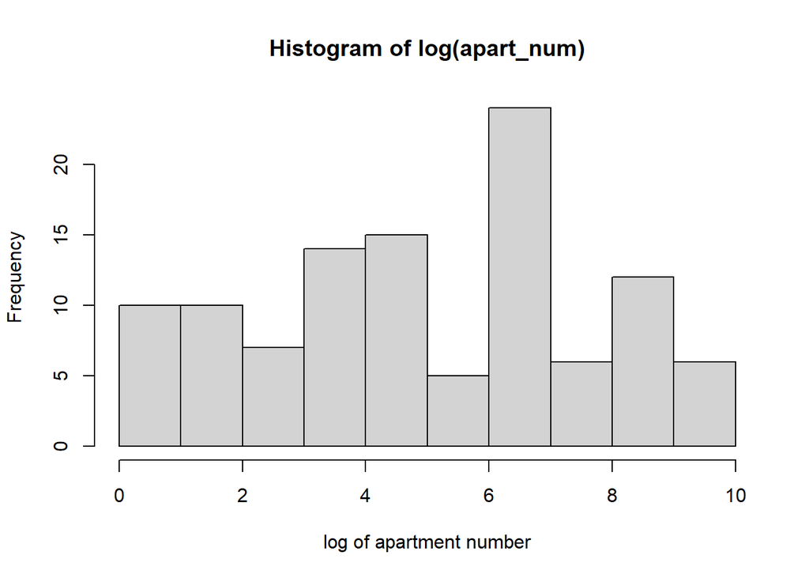

```r
hist(log(apart_num), xlab = "log of apartment number")
```

Part(e):

We first find the leading number for each element in the vector “apart_num”

```r
apart_char <- as.character(apart_num)
first_dig <- as.numeric(substr(apart_char, 1, 1))
```

Then we will construct a vector to store the expected value for each number in sample size of 500. And I just copy the probability of leading digit for each number (1-9) from material that professor provided as store it as a vector named prob

```r
prob <- c(0.301, 0.176, 0.125, 0.097, 0.079, 0.067, 0.058, 0.051, 0.046)#This is our expected probality for leading digit

lead <- as.vector(table(first_dig)) #get count for each number
```

Now, we will conduct a Chi-squared test to check if the leading digit we observed follows Benford’ s law.

```r
chisq.test(lead, p = prob) #conduct a Chi-squared test
```

```
    Chi-squared test for given probabilities

data:  lead
X-squared = 61.646, df = 8, p-value = 2.214e-10
```

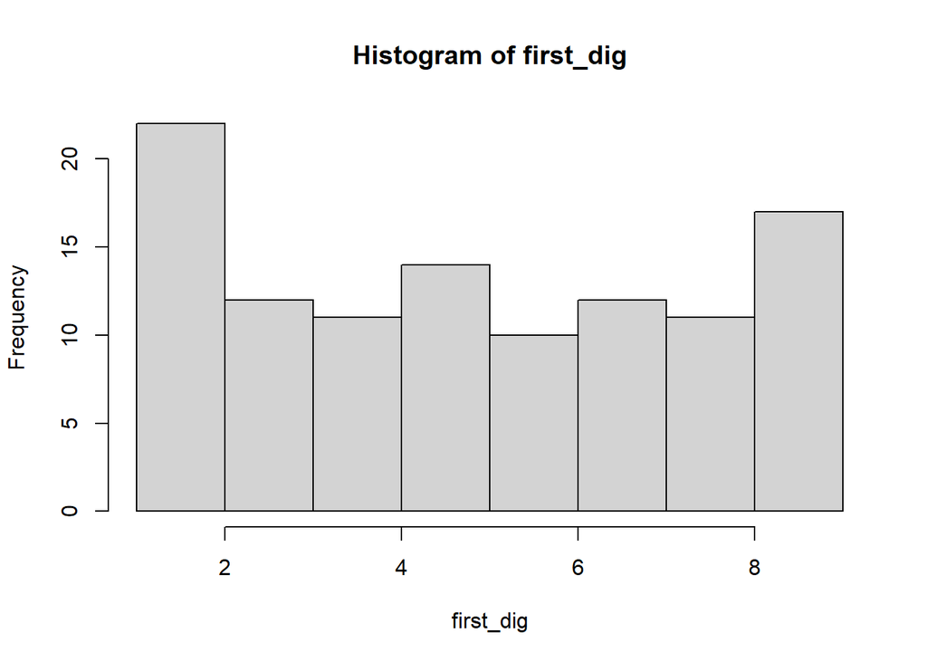

```r
hist(first_dig)
```

Answer : by using Chi-squared test, the p-value is less than 2.214e-10, meaning we will move to alternative hypothesis that the distribution of leading digit what we observed does not follow Benford’s law. Also, we notice in this histogram, we can’t see a decreasing trend, and this tells us our sample does not follow Benford’s law. So maybe the apartment numbers would not pass as real data as we expected(since these data are fake data)

Part(f):

we first find street number for each person

```r
street <- rep(NA, num_row)

for (i in 1: num_row){
  street[i] <- address[[i]][1]
}

# Then I will get the vector of last digit using for loop
last_dig <- rep(NA, num_row)

for (i in 1: num_row){
  last_dig[i] <- as.numeric(substr(street[i], nchar(street[i]), nchar(street[i])))
}
```

Version1: Since I’m not sure if there exist a last digit law, I read some materials from professor provided and I assume the probability of last digit for each number is 0.1. So I will first solve the problem under my assumption.

```r
count_last <- as.vector(table(last_dig))
chisq.test(count_last, p = rep(0.1, 10))
```

```
    Chi-squared test for given probabilities

data:  count_last
X-squared = 11.96, df = 9, p-value = 0.2156
```

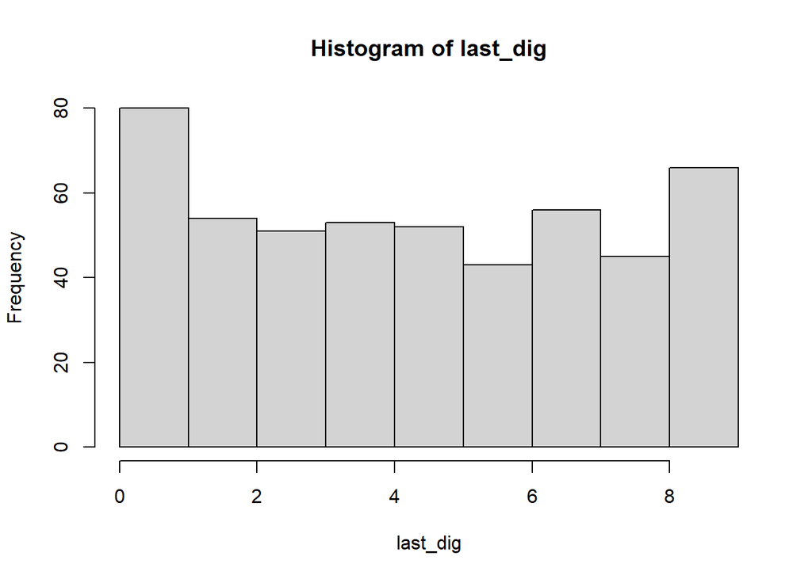

```r
hist(last_dig)
```

The P-value is 0.2156, so if my assumption holds, then we fail to reject H_0, and we may conclude that the last_digit we observed follows Benford’s law of last digit. Also the histogram looks like a discrete uniform distribution

Version2: Now I will assume that the last digit follows Benford’s law of leading digit, then I need to remove all 0’s, and then do a Chi-Squared test

```r
last_dig0 <- last_dig[last_dig != 0] # find those street number not ending at 0
chisq.test(as.vector(table(last_dig0)), p = prob)
```

```
    Chi-squared test for given probabilities

data:  as.vector(table(last_dig0))
X-squared = 237.95, df = 8, p-value < 2.2e-16
```

Then under our assumption, we may say it seems that the last digit we observed does not follow Benford’ s law since we got very small p-value.